# Caterpiller OEE and BIQ Analysis for Lines 6 & 7

### Data management

prepare data to be analyzed by:

1. split data into respective lines
2. add columns to see setups
   - add column to see order number on 7

Columns that are require non-null values had null values dropped.

Rows Dropped: 138

Cleaning up the data a little bit by correcting misspelled words

Now to clean one off PO's to get rid of outlier/bad data

```
2          1" XT-3ES
9        3/4" XT-3ES
14       3/4" XT-6ES
17       3/4" XT-6ES
26       3/4" XT-6ES
            ...
29977    3/4" XT-6ES
29984    3/4" XT-6ES
29985    3/4" XT-6ES
29987    3/4" XT-6ES
29993      1" XT-3ES
Name: Construction, Length: 6869, dtype: object
```

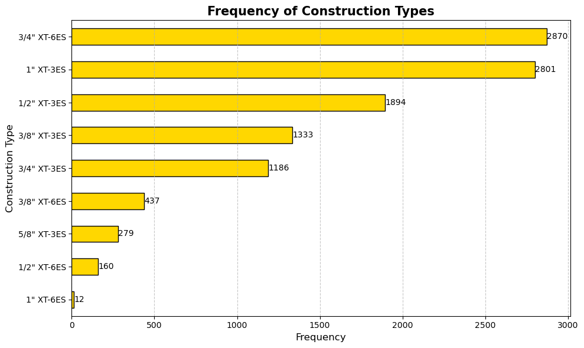

Line 6 has a higher ratio of BIQ to OEE entries showing that Line 6 has either substantially more issues or line 7 is under reporting

```
line|   OEE  | BIQ
----------------------
6   |  6869  | 12828
7   |  4103  | 5496
```

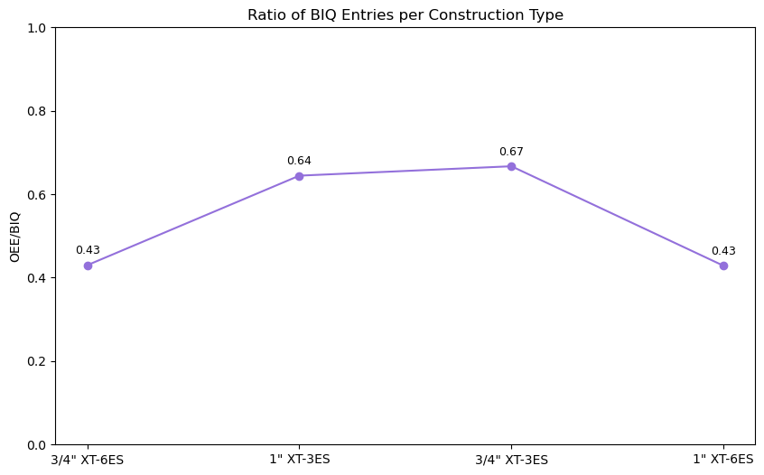

[figure not shown]

|  | ID | Created By | Shift | Date | Operation | Production Order | Construction | Actual Output | Downtime | Defect Description | ... | End Pole | Scrap Footage | Job End Time | Job Start Time | Reflection | TotalTime | OEE Filter | Operator | Mandrel Removed | po |
| --- | --- | --- | --- | --- | --- | --- | --- | --- | --- | --- | --- | --- | --- | --- | --- | --- | --- | --- | --- | --- | --- |
| 4 | 33496 | Jacob Cernetisch | 3rd | 10/26/2023 | LE/FW | 5.001911e+09 | 3/8" XT-6ES | 17 | NaN | NaN | ... | 150 | NaN | 10/26/2023 9:00 | 10/26/2023 1:00 | NaN | 8.00 | OEE | Jacob Cernetisch | NaN | 22.333086 |
| 16 | 33508 | Mark Ryan | 3rd | 10/26/2023 | CE | 5.001911e+09 | 3/8" XT-6ES | 34 | NaN | NaN | ... | 57 | 0 | 10/26/2023 9:05 | 10/26/2023 1:00 | NaN | 8.08 | OEE | Mark Ryan | NaN | 22.333086 |
| 19 | 33511 | Bruce Scharpf | 3rd | 10/26/2023 | EXT | 5.001911e+09 | 3/8" XT-6ES | 20 | NaN | NaN | ... | 70 | 65 | 10/26/2023 5:05 | 10/26/2023 1:00 | ink transfer poles 52, 53, 54, 55, 56, 57, 59,... | 4.08 | OEE | Bruce Scharpf | NaN | 22.333086 |
| 22 | 33514 | Curtis Johnston | 3rd | 10/26/2023 | STW/UW | 5.001911e+09 | 3/8" XT-6ES | 33 | NaN | NaN | ... | 56 | NaN | 10/26/2023 9:00 | 10/26/2023 1:00 | NaN | 8.00 | OEE | Curtis Johnston | NaN | 22.333086 |
| 23 | 33515 | Justin Miller | 3rd | 10/26/2023 | SW | 5.001911e+09 | 3/8" XT-6ES | 31 | NaN | NaN | ... | 58 | 30 | 10/26/2023 9:00 | 10/26/2023 1:00 | NaN | 8.00 | OEE | Justin Miller | NaN | 22.333086 |

5 rows × 26 columns

## Operator Efficiency

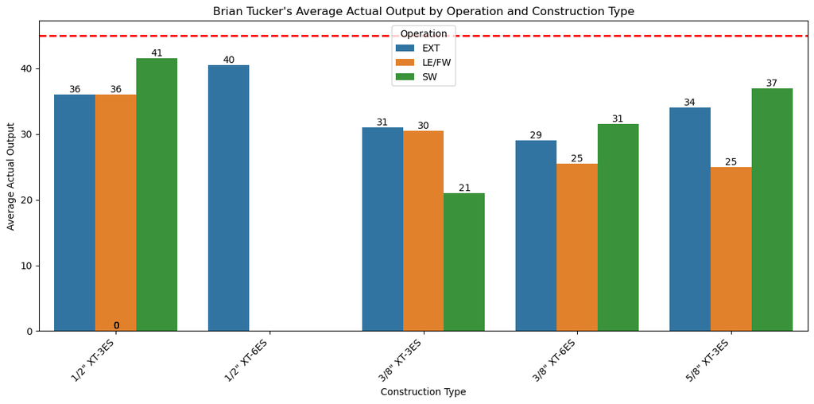

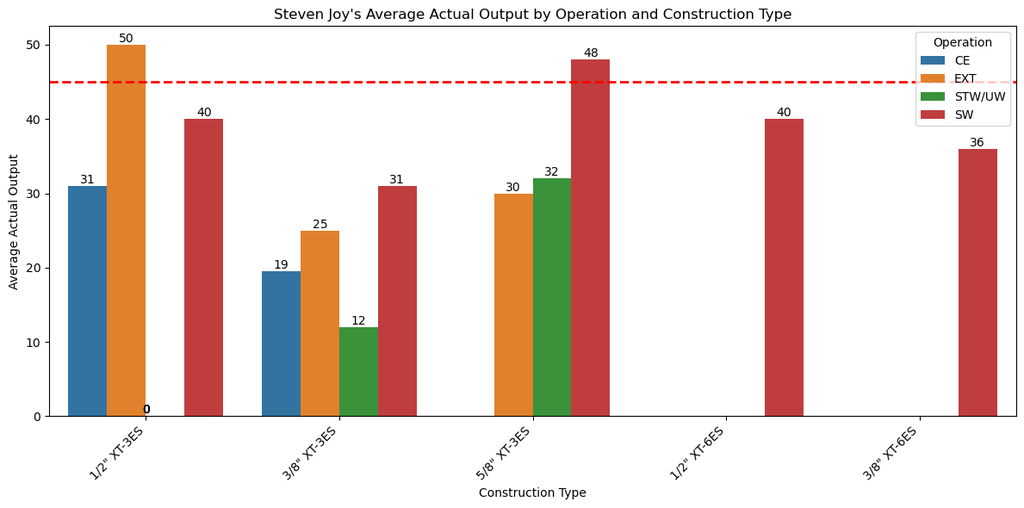

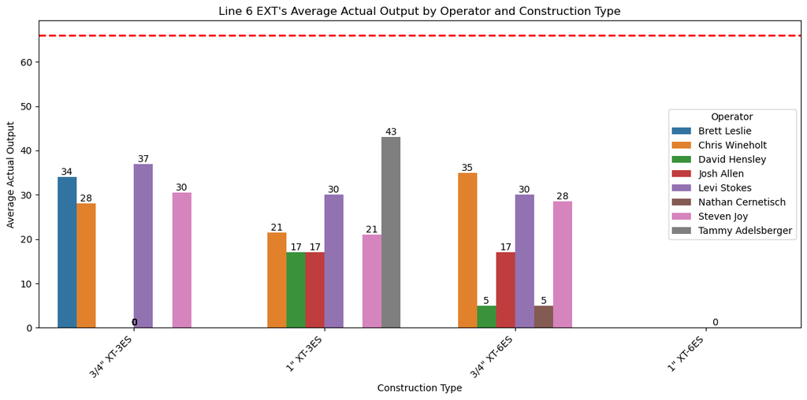

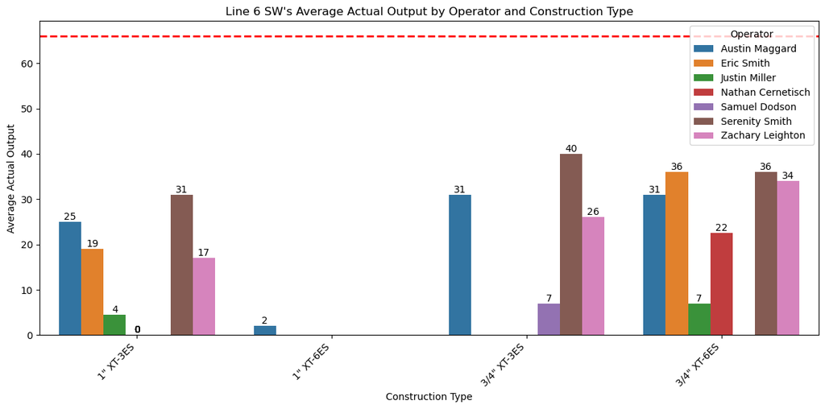

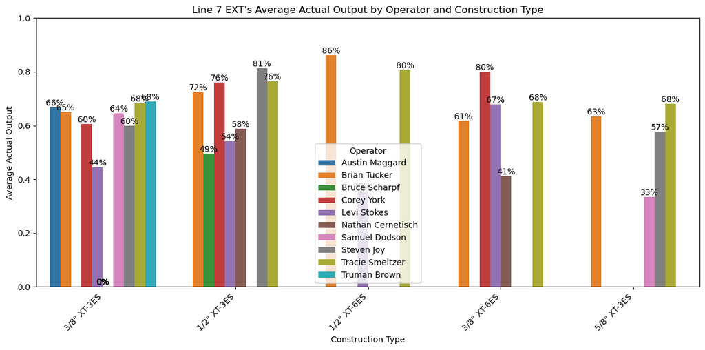

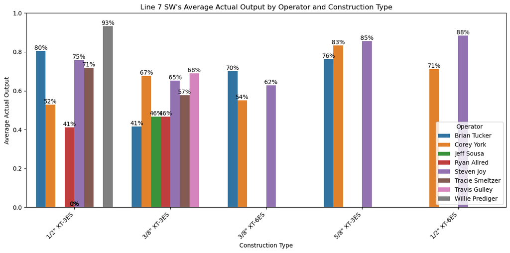

## Setup Time Breakdowns

Status: **rough**

```
Helping with Setup
Spiral Winder Setup
Setup
```

|  | Production Order | Operation | Order | Wire Change |
| --- | --- | --- | --- | --- |
| 23 | 5001911395.0 | SW | 1.0 | 0 |
| 62 | 5001911395.0 | SW | 1.0 | 0 |
| 63 | 5001911395.0 | SW | 1.0 | 0 |
| 85 | 5001911395.0 | SW | 1.0 | 0 |
| 154 | 5001911396.0 | SW | 2.0 | 0 |
| ... | ... | ... | ... | ... |
| 29942 | 5002466565.0 | SW | 2.0 | 30 |
| 29953 | 5002466565.0 | SW | 2.0 | 30 |
| 29874 | 5002466569.0 | SW | 3.0 | 30 |
| 29911 | 5002466569.0 | SW | 3.0 | 30 |
| 29918 | 5002466569.0 | SW | 3.0 | 30 |

2010 rows × 4 columns